# 4.0 Multidimensional Scaling Assignment

# Problem 1

Use the Olympic Heptathlon data, be sure to remove PNG as an outlier and the final scores variable:

```r
data("heptathlon",package="HSAUR2")
mydata <- heptathlon[-25,-8]
```

#### a) Create a scaled distance matrix for observations

This is the scaled distance matrix for the first two coordinates. We can look at the eigenvalues printed or calculate the cumulative proportion of the eigenvalues (commented out) to see that two coordinates is an appropriate number to examine.

```r
cmd <- cmdscale(dist(scale(mydata)), k = 2,  eig = T)
# cumsum(cmd$eig)/sum(cmd$eig)
cmd
```

```
$points
                      [,1]   [,2]
Joyner-Kersee (USA) -4.758 -0.140
John (GDR)          -3.148  0.949
Behmer (GDR)        -2.926  0.695
Sablovskaite (URS)  -1.288  0.179
Choubenkova (URS)   -1.503  0.962
Schulz (GDR)        -0.958  0.351
Fleming (AUS)       -0.953  0.500
Greiner (USA)       -0.633  0.376
Lajbnerova (CZE)    -0.382 -0.712
Bouraga (URS)       -0.522  0.777
Wijnsma (HOL)       -0.218 -0.234
Dimitrova (BUL)     -1.076  0.516
Scheider (SWI)       0.003 -1.447
Braun (FRG)          0.109 -1.636
Ruotsalainen (FIN)   0.209 -0.689
Yuping (CHN)         0.233 -1.960
Hagger (GB)          0.660 -0.088
Brown (USA)          0.757 -2.043
Mulliner (GB)        1.881  0.915
Hautenauve (BEL)     1.828  0.726
Kytola (FIN)         2.118  0.399
Geremias (BRA)       2.771  0.035
Hui-Ing (TAI)        3.901  1.202
Jeong-Mi (KOR)       3.897  0.367

$eig
 [1]  9.9e+01  2.1e+01  1.9e+01  1.1e+01  6.9e+00  2.6e+00  1.6e+00  2.0e-14
 [9]  4.4e-15  3.3e-15  2.6e-15  2.0e-15  6.5e-16  2.3e-16  1.9e-16 -2.9e-16
[17] -3.4e-16 -1.3e-15 -1.3e-15 -3.1e-15 -4.2e-15 -4.2e-15 -4.4e-15 -8.7e-15

$x
NULL

$ac
[1] 0

$GOF
[1] 0.75 0.75
```

#### b) Perform graphical MDS analysis on the “distance” matrix of a

*Label the points using the row names (set an appropriate cex (size) for a better view). Who is the most similar athlete to Scheider(SWI)?*

This is the plot of the scaled distances, from this we can see that Braun from FRG (West Germany) is the closest toe Scheider.

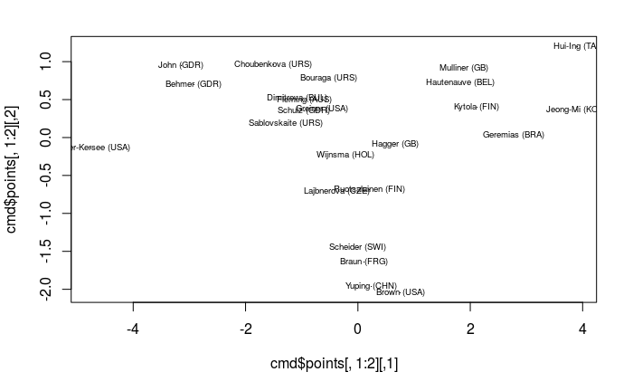

```r
plot(cmd$points[,1:2], pch = ".")
text(cmd$points[,1:2], labels = rownames(mydata), cex = 0.6)
```

#### c) Create a distance matrix from a correlation matrix, explain why this represents distance between variables

*Create a correlation matrix, convert it to a distance matrix by computing 1-correlation* This is a distance matrix created by performing 1 - the correlation matrix of the data. The resulting distances can be understood relative to their correlations, with a distance of zero being perfect correlation. Therefore, higher distances in this matrix represent lower correlations and vice versa.

```r
v.dist <- 1-cor(mydata)
v.dist
```

```
         hurdles highjump shot run200m longjump javelin run800m
hurdles     0.00     1.58 1.77    0.17     1.89    1.33    0.44
highjump    1.58     0.00 0.54    1.39     0.34    0.65    1.15
shot        1.77     0.54 0.00    1.67     0.22    0.66    1.41
run200m     0.17     1.39 1.67    0.00     1.81    1.47    0.43
longjump    1.89     0.34 0.22    1.81     0.00    0.71    1.52
javelin     1.33     0.65 0.66    1.47     0.71    0.00    1.26
run800m     0.44     1.15 1.41    0.43     1.52    1.26    0.00
```

#### d) Perform graphical MDS analysis on the correlation-distance matrix

*Label the points using the column names (set an appropriate cex (size) for a better view). What variables are more similar (related) to each other?* This is the MDS plot of the correlation-distance matrix created above. Unfortunately it is difficult to tell which variables are related regardless of how the text is scaled, but there are obvious clusters and the ones near the bottom would be the most closely related.

[figure not shown]

```r
v.cmd <- cmdscale(v.dist, eig = T)
plot(v.cmd$points[,1:2], pch = ".")
text(v.cmd$points[,1:2], labels = rownames(mydata), cex = .4)
```

# Problem 2

Use the TTU grad student exit survey data. Two variables of interest are FacTeaching, a 1, 2, 3, 4, 5 ratings of teaching at TTU by the student, and COL, the college from which the student graduated.

```r
grad <- read.csv("http://westfall.ba.ttu.edu/isqs6348/Rdata/pgs.csv", header = T)
```

```r
install.packages("ca")
```

```r
library(ca)
```

#### a) Construct the contingency table showing counts of students in all combinations of these two variables

```r
attach(grad)
tbl = table(COL, FacTeaching)
tbl
```

```
      FacTeaching
COL      1   2   3   4   5
  AG     4  15  26  78  56
  AR     3   4   6  16   4
  AS    12  24 124 290 171
  BA     9  28  44 116  66
  DUAL   0   0   2   0   0
  ED     3   6  26 113  93
  EN     5  36  65 168  86
  GR     0   3   8  27  15
  HS     1   5  17  41  33
  MC     0   0   3  25   6
  VPA    4   7  10  37  44
```

#### b) Construct the correspondence analysis (CA) plot and comment on the outlier in the previous problem

*Remove the outlier data you discovered and re-construct the CA plot.* Using the `ca()` function, we create a CA plot of the evaluation data. One obvious outlier is “Dual,” which has an extremely low count. This may be because students who are dual majors are counted in other categories, or there are just very few of them. We can remove it before executing the final plot.

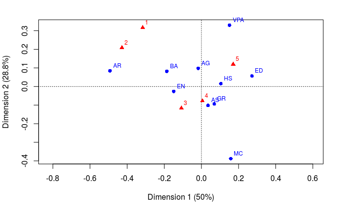

```r
grad.ca <- ca(tbl)
grad.ca <- ca(tbl2 <- tbl[-5, ])
plot(grad.ca)
```

#### c) Analysis of three selected colleges

*Pick three colleges in your graph, two of which are close to each other, and the third of which is far from your first two. Find the three conditional distributions of rating for your three colleges, and interpret the distance between the graph points in terms of “distances” between those three conditional distributions.*

R-Documentation: - `prop.table` returns conditional proportions given margins, i.e. entries of x, divided by the appropriate marginal sums.

1. First we create the proportion table with the `prop.table()` function:

```r
tbl2 <- tbl[-5, ]

# create proportion table
prop.tbl2 <- prop.table(tbl2)
round(prop.tbl2, 3)
```

```
     FacTeaching
COL       1     2     3     4     5
  AG  0.002 0.008 0.013 0.039 0.028
  AR  0.002 0.002 0.003 0.008 0.002
  AS  0.006 0.012 0.063 0.146 0.086
  BA  0.005 0.014 0.022 0.058 0.033
  ED  0.002 0.003 0.013 0.057 0.047
  EN  0.003 0.018 0.033 0.085 0.043
  GR  0.000 0.002 0.004 0.014 0.008
  HS  0.001 0.003 0.009 0.021 0.017
  MC  0.000 0.000 0.002 0.013 0.003
  VPA 0.002 0.004 0.005 0.019 0.022
```

2. Let’s examine an apparent cluster of three schools: BA, EN, and MC BA and EN appear close, while MC is extremely far from both.

```r
prop.table(tbl2, 1)[c(4, 6, 9), ]
```

```
    FacTeaching
COL      1     2     3     4     5
  BA 0.034 0.106 0.167 0.441 0.251
  EN 0.014 0.100 0.181 0.467 0.239
  MC 0.000 0.000 0.088 0.735 0.176
```

The distances between BA and EN are extremely close between all scores with the exception of 1, and BA is visibly close to 1 on the graph. MC is far on most of the scores, with most of the proportion centered on 4. It is weighted significantly towards higher scores in general.

# Problem 3

Use the Daily stock returns data set. The columns are companies; Man1, Man2, Man3 are manufacturing companies; Serv1, Serv2, Serv3, Serv4 are service companies.The numbers (returns) are all small, close to zero, and this causes some numerical problems with the computer analyses. (As a general rule, numerical algorithms are designed for stability when the numbers are “nice,” like 12.3, 4.56, 2.38 rather than .000123, .0000456, .0000238.) So multiply everything in the data set by 100 first. (This converts returns to % scale; eg, 0.013 becomes 1.3%).

```r
stock <- read.csv("https://bit.ly/3egKiMU")
stock = stock*100
```

#### a) Perform an exploratory factor analysis (EFA) using two factors.

To perform a basic EFA, we will use the `factanal()` function and pass in `factors = 2` to specify the number of factors.

```r
stock.fa<- factanal(stock, factors = 2)
stock.fa
```

```
Call:
factanal(x = stock, factors = 2)

Uniquenesses:
 Man1  Man2  Man3 Serv1 Serv2 Serv3 Serv4
 0.76  0.51  0.52  0.90  0.71  0.79  0.57

Loadings:
      Factor1 Factor2
Man1  0.46    0.15
Man2  0.67    0.18
Man3  0.68    0.15
Serv1 0.13    0.29
Serv2 0.13    0.52
Serv3 0.13    0.44
Serv4 0.14    0.64

               Factor1 Factor2
SS loadings       1.20    1.03
Proportion Var    0.17    0.15
Cumulative Var    0.17    0.32

Test of the hypothesis that 2 factors are sufficient.
The chi square statistic is 5.1 on 8 degrees of freedom.
The p-value is 0.75
```

#### b) Interpret the p-value reported in your EFA.

The null hypothesis is that the number of factors is sufficient for presenting the data. With a p-value of 0.75, we fail to reject the null hypothesis.

#### c) What are the factors (latent variables) in this model? Name them.

The factors are the types of companies, namely manufacturing and service. This is apparent from the clustered loadings of each company type.

#### d) Write the EFA regression model for variable Man1.

*For example: Man1 = a f1 + b f2 + e. Based on the outputs, what are a and b?* *Note: e is an unknown error term random variable (called u in the lecture video). The most important thing we know about e is the variance of e, which we call it uniqueness, also we know that e is normally distributed with the mean of zero. Long story short, do not plug a value for e because it’s a random variable, not a constant value.* The regression model for Man1 uses the coefficients of the loadings and the additional error term. $Man1 = 0.46f_1 + 0.15f_2 + e$

#### e) In the model of part d, determine the variance of the error term e.

Knowing that the variance of the scaled variable is unit, we can solve for the error term and establish that the variance of the error term (uniqueness) is one minus the sum of squared loadings:

$Var(e_i) = 1 - (λ^2_{i1} + λ^2_{i2} +...+λ^2_{ik})$

We can calculate this in R and arrive at a uniqueness of 0.76:

```r
1 - sum(stock.fa$loadings[1,1:2]^2)
```

```
[1] 0.76
```

#### f) What is the correlation between f2 and Serve2?

From the analysis above we can find this at 0.52.

#### g) Compare the EFA approximated correlation matrix versus the actual correlation matrix. Report RMSE. What do you conclude?

To perform the extimated correlation, we use the formula:

$\hatΣ = ΛΛ^T + Ψ$

Multiply the loadings matrix by its transpose and add the covariance matrix of error. Then we can perform the RMSE on that result and the original correlation matrix. From the result of 0.01 it appears the matrices have low error and are therefore very similar

```r
s.loadings = stock.fa$loadings[,1:2]
corHat <- s.loadings %*% t(s.loadings) + diag(stock.fa$uniquenesses)

corr <- cor(stock)
rmse = sqrt(mean((corHat-corr)^2))
rmse
```

```
[1] 0.01
```

# Problem 4

Perform factor analysis on questions 22-35 of TTU web survey data:

```r
ttuweb <- read.csv("https://bit.ly/3oNr5qX")
mydata <- ttuweb[,22:35]
```

#### a) There are some missing values in this data. Find the correlation matrix based on pair-wise deletion.

*Use this correlation matrix as an input for EFA.*

The nulls can be dropped by performing a correlation and passing in pairwise for the `use` argument:

```r
cleandata <- cor(mydata, use = "pairwise.complete.obs")
head(cleandata)
```

```
     Q22  Q23  Q24  Q25  Q26  Q27  Q28  Q29   Q30   Q31   Q32   Q33    Q34   Q35
Q22 1.00 0.61 0.56 0.56 0.52 0.50 0.54 0.52 -0.25 -0.37 -0.27 -0.26 -0.182 -0.35
Q23 0.61 1.00 0.66 0.60 0.55 0.55 0.57 0.50 -0.16 -0.28 -0.29 -0.22 -0.103 -0.24
Q24 0.56 0.66 1.00 0.57 0.52 0.48 0.53 0.44 -0.14 -0.28 -0.26 -0.23 -0.048 -0.23
Q25 0.56 0.60 0.57 1.00 0.47 0.46 0.48 0.45 -0.21 -0.30 -0.17 -0.25 -0.185 -0.32
Q26 0.52 0.55 0.52 0.47 1.00 0.77 0.74 0.70 -0.26 -0.33 -0.29 -0.19 -0.099 -0.28
Q27 0.50 0.55 0.48 0.46 0.77 1.00 0.69 0.66 -0.23 -0.29 -0.28 -0.23 -0.036 -0.29
```

#### b) Perform EFA suggesting two common factors. How would you name those factors?

*You find corr in part a, then you can perform EFA based on the corr matrix given knowing the size of the original data. This is the expected outcome*

fter performing EFA, the two factors group around types of questions. Factor one appears to be attitudes towards the university, and Factor two is related to opinions about the website.

```r
cleandata = na.omit(mydata)
cleandata.fa <- factanal(cleandata, factors = 2)
cleandata.fa
```

```
Call:
factanal(x = cleandata, factors = 2)

Uniquenesses:
 Q22  Q23  Q24  Q25  Q26  Q27  Q28  Q29  Q30  Q31  Q32  Q33  Q34  Q35
0.53 0.52 0.58 0.61 0.30 0.38 0.20 0.29 0.61 0.45 0.49 0.51 0.62 0.65

Loadings:
    Factor1 Factor2
Q22  0.615  -0.297
Q23  0.665  -0.205
Q24  0.615  -0.195
Q25  0.573  -0.254
Q26  0.823  -0.162
Q27  0.773  -0.148
Q28  0.893
Q29  0.838
Q30 -0.156   0.604
Q31 -0.287   0.683
Q32 -0.198   0.688
Q33 -0.109   0.694
Q34          0.615
Q35 -0.206   0.557

               Factor1 Factor2
SS loadings       4.50    2.77
Proportion Var    0.32    0.20
Cumulative Var    0.32    0.52

Test of the hypothesis that 2 factors are sufficient.
The chi square statistic is 289 on 64 degrees of freedom.
The p-value is 2.1e-30
```

#### c) Perform EFA suggesting three common factors. How would you name those factors?

```r
cleandata.fa
```

[output not shown]

#### d) What rotation method is used in factanal as a default method? Explain what that rotation does?

Rotation changes the factor loadings with the goal of making them easier to interpret. The default rotation method is varimax.

#### e) Repeat part b (EFA with two factors) without rotation (inside factanal put rotation = “none”)

*Will you end up with the same names for your factors?*

```r
cleandata = na.omit(mydata)
cleandata.fa <- factanal(cleandata, factors = 2, rotation = "none")
cleandata.fa
```

```
Call:
factanal(x = cleandata, factors = 2, rotation = "none")

Uniquenesses:
 Q22  Q23  Q24  Q25  Q26  Q27  Q28  Q29  Q30  Q31  Q32  Q33  Q34  Q35
0.53 0.52 0.58 0.61 0.30 0.38 0.20 0.29 0.61 0.45 0.49 0.51 0.62 0.65

Loadings:
    Factor1 Factor2
Q22  0.681
Q23  0.695
Q24  0.645
Q25  0.626
Q26  0.827   0.139
Q27  0.776   0.135
Q28  0.862   0.245
Q29  0.812   0.221
Q30 -0.359   0.510
Q31 -0.510   0.537
Q32 -0.428   0.574
Q33 -0.347   0.611
Q34 -0.247   0.564
Q35 -0.389   0.448

               Factor1 Factor2
SS loadings       5.34    1.92
Proportion Var    0.38    0.14
Cumulative Var    0.38    0.52

Test of the hypothesis that 2 factors are sufficient.
The chi square statistic is 289 on 64 degrees of freedom.
The p-value is 2.1e-30
```